# CourseProject for Practical Machine Learning

Sergey Nazarov

Saturday, November 21, 2015

## This submission builds a machine learning algorithm to predict activity quality from activity monitors.

This analisys includes loading data, creating validation set for estimating out of sample error, getting rid of NA variables and some other strange looking variables, checking for hihgly correlated variables and creating a model using random forest. The training data for this project are available here: https://d396qusza40orc.cloudfront.net/predmachlearn/pml-training.csv  
The test data are available here:  
https://d396qusza40orc.cloudfront.net/predmachlearn/pml-testing.csv

```r
library(caret); library(randomForest) # library needed for this analisys
```

#### After loading data from the web, using links above, read the data into r

```r
training <- read.csv("C:/Users/Sergey/Coursera/PracticalMachineLearning/CourseProject/rawdata/training.csv")
testing <- read.csv("C:/Users/Sergey/Coursera/PracticalMachineLearning/CourseProject/rawdata/testing.csv")
```

#### Creating validation set which will be used to estimate out of sample error:

```r
inTrain <- createDataPartition(y=training$classe, p = 0.7, list = FALSE)
training <- training[inTrain, ]
validation <- training[-inTrain, ]
```

#### getting rid off variables that have > 95% of Na’s

```r
training <- training[, !colSums(is.na(training))/dim(training)[1] > 0.95]
```

checking how many NA’s left

```r
colSums(is.na(training))[colSums(is.na(training)) != 0]
```

```
## named numeric(0)
```

no NA’s left, so there is no need to use impute technics  
we have now only 93 variables instead of 160, but there are several factor variables which have “” as a value  
#### getting rid off variables that have > 95% of “” as value

```r
x <- NULL
for (i in 1 : 93) {
    if  (sum(training[, i] == "")/93 > 0.95) {
            x <- c(x, i)
    }
}

training <- training[, -x]
```

so we have only 60 variables checking are there factor variables which has “” as a value

```r
sum(training[, 1:60] == "")
```

```
## [1] 0
```

no “” left, so no need to use impute technics  
and of course output cannot depend on name, on day and time or on any of the first 7 variables

```r
training <- training[, - (1:7)] # throw first 7 variable out of training set
```

#### checking Near Zero variables

```r
nsv <- nearZeroVar(training, saveMetrics = TRUE) # all FALSE, so nothing to do
```

#### highly corelated variables?

```r
M <- abs(cor(training[, -53]))
diag(M) <- 0
dim(which(M > 0.9, arr.ind=T))
```

```
## [1] 22  2
```

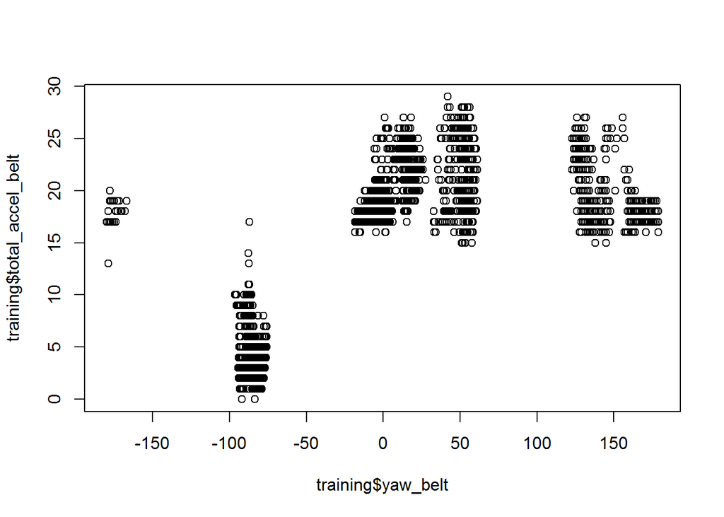

```r
plot(training$yaw_belt, training$total_accel_belt) # does corelation looks like this? not sure
```

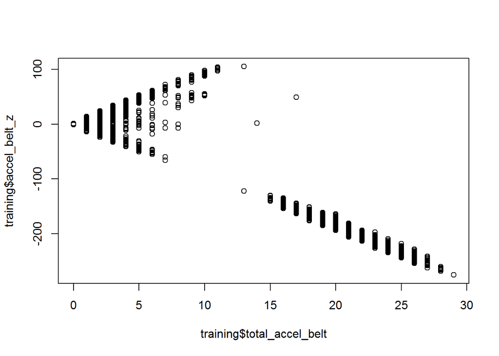

```r
plot(training$total_accel_belt, training$accel_belt_z) # maybe like this, not sure
```

#### i will not do any PCA processing now, but i will return to this highly correlated variables if my model produce wrong results

#### lets look at training set

```r
summary(training)
```

```
##    roll_belt        pitch_belt          yaw_belt       total_accel_belt
##  Min.   :-28.90   Min.   :-55.8000   Min.   :-180.00   Min.   : 0.00
##  1st Qu.:  1.10   1st Qu.:  1.7100   1st Qu.: -88.30   1st Qu.: 3.00
##  Median :113.00   Median :  5.2800   Median : -13.40   Median :17.00
##  Mean   : 64.15   Mean   :  0.2414   Mean   : -11.42   Mean   :11.28
##  3rd Qu.:123.00   3rd Qu.: 14.8000   3rd Qu.:  10.90   3rd Qu.:18.00
##  Max.   :162.00   Max.   : 60.3000   Max.   : 179.00   Max.   :29.00
##   gyros_belt_x        gyros_belt_y       gyros_belt_z
##  Min.   :-1.040000   Min.   :-0.64000   Min.   :-1.4600
##  1st Qu.:-0.050000   1st Qu.: 0.00000   1st Qu.:-0.2000
##  Median : 0.030000   Median : 0.02000   Median :-0.1000
##  Mean   :-0.006803   Mean   : 0.03948   Mean   :-0.1302
##  3rd Qu.: 0.110000   3rd Qu.: 0.11000   3rd Qu.:-0.0200
##  Max.   : 2.200000   Max.   : 0.64000   Max.   : 1.6100
##   accel_belt_x      accel_belt_y     accel_belt_z    magnet_belt_x
##  Min.   :-82.000   Min.   :-69.00   Min.   :-275.0   Min.   :-52.00
##  1st Qu.:-21.000   1st Qu.:  3.00   1st Qu.:-162.0   1st Qu.:  9.00
##  Median :-15.000   Median : 33.00   Median :-151.0   Median : 35.00
##  Mean   : -5.484   Mean   : 30.02   Mean   : -72.2   Mean   : 55.66
##  3rd Qu.: -5.000   3rd Qu.: 61.00   3rd Qu.:  28.0   3rd Qu.: 59.00
##  Max.   : 85.000   Max.   :150.00   Max.   : 105.0   Max.   :485.00
##  magnet_belt_y   magnet_belt_z       roll_arm         pitch_arm
##  Min.   :354.0   Min.   :-623.0   Min.   :-180.00   Min.   :-88.800
##  1st Qu.:581.0   1st Qu.:-375.0   1st Qu.: -31.20   1st Qu.:-26.000
##  Median :601.0   Median :-319.0   Median :   0.00   Median :  0.000
##  Mean   :593.6   Mean   :-345.7   Mean   :  18.02   Mean   : -4.575
##  3rd Qu.:610.0   3rd Qu.:-306.0   3rd Qu.:  77.20   3rd Qu.: 11.500
##  Max.   :673.0   Max.   : 293.0   Max.   : 179.00   Max.   : 88.500
##     yaw_arm         total_accel_arm  gyros_arm_x        gyros_arm_y
##  Min.   :-180.000   Min.   : 1.00   Min.   :-6.37000   Min.   :-3.4400
##  1st Qu.: -43.400   1st Qu.:17.00   1st Qu.:-1.33000   1st Qu.:-0.8000
##  Median :   0.000   Median :27.00   Median : 0.08000   Median :-0.2400
##  Mean   :  -0.732   Mean   :25.56   Mean   : 0.04565   Mean   :-0.2594
##  3rd Qu.:  45.900   3rd Qu.:33.00   3rd Qu.: 1.57000   3rd Qu.: 0.1400
##  Max.   : 180.000   Max.   :66.00   Max.   : 4.87000   Max.   : 2.8400
##   gyros_arm_z       accel_arm_x       accel_arm_y       accel_arm_z
##  Min.   :-2.3300   Min.   :-404.00   Min.   :-318.00   Min.   :-636.00
##  1st Qu.:-0.0800   1st Qu.:-243.00   1st Qu.: -54.00   1st Qu.:-143.00
##  Median : 0.2300   Median : -47.00   Median :  14.00   Median : -47.00
##  Mean   : 0.2674   Mean   : -61.18   Mean   :  33.08   Mean   : -71.33
```

[output cut: 50 more lines]

```
##  Max.   :311.00000   Max.   :231.0000   Max.   : 477.00   Max.   : 923.0
##  accel_forearm_z   magnet_forearm_x  magnet_forearm_y magnet_forearm_z
##  Min.   :-446.00   Min.   :-1280.0   Min.   :-896.0   Min.   :-973.0
##  1st Qu.:-182.00   1st Qu.: -613.0   1st Qu.:   8.0   1st Qu.: 194.0
##  Median : -39.00   Median : -371.0   Median : 595.0   Median : 512.0
##  Mean   : -55.39   Mean   : -309.8   Mean   : 381.5   Mean   : 395.8
##  3rd Qu.:  26.00   3rd Qu.:  -69.0   3rd Qu.: 738.0   3rd Qu.: 654.0
##  Max.   : 291.00   Max.   :  672.0   Max.   :1480.0   Max.   :1070.0
##  classe
##  A:3906
##  B:2658
##  C:2396
##  D:2252
##  E:2525
##
```

#### in general variables looks good, except some outliers

#### i won’t do anything with outliers now, but i will return to this issue if my model produce wrong results

## Creating prediction model

```r
set.seed(12345)
rfmodelFit <- train(classe ~ ., data = training, method = "rf",
                     trControl = trainControl(method = "cv", number = 3))
rfmodelFit
```

```
## Random Forest
##
## 13737 samples
##    52 predictor
##     5 classes: 'A', 'B', 'C', 'D', 'E'
##
## No pre-processing
## Resampling: Cross-Validated (3 fold)
## Summary of sample sizes: 9159, 9158, 9157
## Resampling results across tuning parameters:
##
##   mtry  Accuracy   Kappa      Accuracy SD  Kappa SD
##    2    0.9880619  0.9848982  0.003282980  0.004151576
##   27    0.9870424  0.9836071  0.002849736  0.003607276
##   52    0.9800539  0.9747626  0.002964914  0.003759792
##
## Accuracy was used to select the optimal model using  the largest value.
## The final value used for the model was mtry = 2.
```

#### Accuracy is 0.98, it is very good, but how much is it biased?

```r
confusionMatrix(predict(rfmodelFit, newdata = validation), validation$classe)
```

```
## Confusion Matrix and Statistics
##
##           Reference
## Prediction    A    B    C    D    E
##          A 1160    0    0    0    0
##          B    0  810    0    0    0
##          C    0    0  725    0    0
##          D    0    0    0  670    0
##          E    0    0    0    0  747
##
## Overall Statistics
##
##                Accuracy : 1
##                  95% CI : (0.9991, 1)
##     No Information Rate : 0.2821
##     P-Value [Acc > NIR] : < 2.2e-16
##
##                   Kappa : 1
##  Mcnemar's Test P-Value : NA
##
## Statistics by Class:
##
##                      Class: A Class: B Class: C Class: D Class: E
## Sensitivity            1.0000    1.000   1.0000   1.0000   1.0000
## Specificity            1.0000    1.000   1.0000   1.0000   1.0000
## Pos Pred Value         1.0000    1.000   1.0000   1.0000   1.0000
## Neg Pred Value         1.0000    1.000   1.0000   1.0000   1.0000
## Prevalence             0.2821    0.197   0.1763   0.1629   0.1817
## Detection Rate         0.2821    0.197   0.1763   0.1629   0.1817
## Detection Prevalence   0.2821    0.197   0.1763   0.1629   0.1817
## Balanced Accuracy      1.0000    1.000   1.0000   1.0000   1.0000
```